# Introduction to dataSDA

Datasets and Basic Statistics for Symbolic Data Analysis

Po-Wei Chen, Chun-houh Chen and Han-Ming Wu

March 14, 2026

# 1 Introduction

The `dataSDA` package (v0.2.4) gathers various symbolic data tailored to different research themes and provides a comprehensive set of functions for reading, writing, converting, and analyzing symbolic data. The package is available on CRAN at https://CRAN.R-project.org/package=dataSDA and on GitHub at https://github.com/hanmingwu1103/dataSDA.

The package includes **114 datasets** spanning seven types of symbolic data. Each dataset name uses a suffix that indicates its type:

Dataset counts by type

[output not shown]

| Type | Datasets |
| --- | --- |
| Interval (.int) | 54 |
| Histogram (.hist) | 25 |
| Mixed (.mix) | 11 |
| Interval Time Series (.its) | 9 |
| Modal (.modal) | 7 |
| Distributional (.distr) | 3 |
| Interval (.iGAP) | 2 |
| Other | 2 |
| Interval (.int.mm) | 1 |

The package provides functions organized into the following categories:

| Category | Functions | Count |
| --- | --- | --- |
| Format detection & conversion | `int_detect_format`, `int_list_conversions`, `int_convert_format`, `RSDA_to_MM`, `iGAP_to_MM`, `SODAS_to_MM`, `MM_to_iGAP`, `RSDA_to_iGAP`, `SODAS_to_iGAP`, `MM_to_RSDA`, `iGAP_to_RSDA` | 11 |
| Core statistics | `int_mean`, `int_var`, `int_cov`, `int_cor` | 4 |
| Geometric properties | `int_width`, `int_radius`, `int_center`, `int_midrange`, `int_overlap`, `int_containment` | 6 |
| Position & scale | `int_median`, `int_quantile`, `int_range`, `int_iqr`, `int_mad`, `int_mode` | 6 |
| Robust statistics | `int_trimmed_mean`, `int_winsorized_mean`, `int_trimmed_var`, `int_winsorized_var` | 4 |
| Distribution shape | `int_skewness`, `int_kurtosis`, `int_symmetry`, `int_tailedness` | 4 |
| Similarity measures | `int_jaccard`, `int_dice`, `int_cosine`, `int_overlap_coefficient`, `int_tanimoto`, `int_similarity_matrix` | 6 |
| Uncertainty & variability | `int_entropy`, `int_cv`, `int_dispersion`, `int_imprecision`, `int_granularity`, `int_uniformity`, `int_information_content` | 7 |
| Distance measures | `int_dist`, `int_dist_matrix`, `int_pairwise_dist`, `int_dist_all` | 4 |
| Histogram statistics | `hist_mean`, `hist_var`, `hist_cov`, `hist_cor` | 4 |
| Utilities | `clean_colnames`, `RSDA_format`, `set_variable_format`, `read_symbolic_csv`, `write_symbolic_csv` | 5 |

# 2 Data Formats and Conversion

## 2.1 Interval data formats overview

The `dataSDA` package works with three primary formats for interval-valued data:

- **RSDA format**: `symbolic_tbl` objects where intervals are encoded as complex numbers (`min + max*i`). Used by the `RSDA` package.
- **MM format**: Standard data frames with paired `_min` / `_max` columns for each variable.
- **iGAP format**: Data frames where each interval is a comma-separated string (e.g., `"2.5,4.0"`).

```r
data(mushroom.int)
head(mushroom.int, 3)
```

```
#> # A tibble: 3 × 5
#>   Species Pileus.Cap.Width   Stipe.Length Stipe.Thickness Edibility
#>   <chr>         <symblc_n>     <symblc_n>      <symblc_n> <chr>
#> 1 arorae     [3.00 : 8.00]  [4.00 : 9.00]   [0.50 : 2.50] U
#> 2 arvenis   [6.00 : 21.00] [4.00 : 14.00]   [1.00 : 3.50] Y
#> 3 benesi     [4.00 : 8.00] [5.00 : 11.00]   [1.00 : 2.00] Y
```

```r
class(mushroom.int)
```

```
#> [1] "symbolic_tbl" "tbl_df"       "tbl"          "data.frame"
```

```r
data(abalone.int)
head(abalone.int, 3)
```

```
#>         Length_min Length_max Diameter_min Diameter_max Height_min Height_max
#> F-10-12     0.1275     0.9975        0.075        0.815    -0.0175     0.3125
#> F-13-15     0.1775     1.0275        0.125        0.825      0.025      0.325
#> F-16-18       0.22       0.92       0.1725       0.7425     0.0375     0.3075
#>         Whole_min Whole_max Shucked_min Shucked_max Viscera_min Viscera_max
#> F-10-12    -1.021     3.883     -0.6322      2.1948     -0.2077      0.7712
#> F-13-15   -0.8567    3.6303     -0.4548      1.7942     -0.1905      0.7555
#> F-16-18   -0.5725    3.1235      -0.244       1.206     -0.1037      0.6752
#>         Shell_min Shell_max
#> F-10-12    -0.258     1.054
#> F-13-15    -0.269     1.153
#> F-16-18   -0.3233    1.4477
```

```r
class(abalone.int)
```

```
#> [1] "data.frame"
```

```r
data(abalone.iGAP)
head(abalone.iGAP, 3)
```

```
#>                 Length       Diameter          Height           Whole
#> F-10-12  0.1275,0.9975   0.075, 0.815 -0.0175, 0.3125   -1.021, 3.883
#> F-13-15  0.1775,1.0275    0.125,0.825    0.025, 0.325 -0.8567, 3.6303
#> F-16-18      0.22,0.92 0.1725, 0.7425  0.0375, 0.3075 -0.5725, 3.1235
#>                 Shucked         Viscera           Shell
#> F-10-12 -0.6322, 2.1948 -0.2077, 0.7712   -0.258, 1.054
#> F-13-15 -0.4548, 1.7942 -0.1905, 0.7555   -0.269, 1.153
#> F-16-18   -0.244, 1.206 -0.1037, 0.6752 -0.3233, 1.4477
```

```r
class(abalone.iGAP)
```

```
#> [1] "data.frame"
```

The `int_detect_format()` function automatically identifies the format of a dataset:

```r
int_detect_format(mushroom.int)
```

```
#> [1] "RSDA"
```

```r
int_detect_format(abalone.int)
```

```
#> [1] "MM"
```

```r
int_detect_format(abalone.iGAP)
```

```
#> [1] "iGAP"
```

Use `int_list_conversions()` to see all available format conversion paths:

```r
int_list_conversions()
```

```
#>     from    to  function_name
#> 1   RSDA    MM     RSDA_to_MM
#> 2   RSDA  iGAP   RSDA_to_iGAP
#> 3   RSDA ARRAY  RSDA_to_ARRAY
#> 4     MM  iGAP     MM_to_iGAP
#> 5     MM  RSDA     MM_to_RSDA
#> 6     MM ARRAY    MM_to_ARRAY
#> 7   iGAP    MM     iGAP_to_MM
#> 8   iGAP  RSDA   iGAP_to_RSDA
#> 9   iGAP ARRAY  iGAP_to_ARRAY
#> 10 ARRAY  RSDA  ARRAY_to_RSDA
#> 11 ARRAY    MM    ARRAY_to_MM
#> 12 ARRAY  iGAP  ARRAY_to_iGAP
#> 13 SODAS    MM    SODAS_to_MM
#> 14 SODAS  iGAP  SODAS_to_iGAP
#> 15 SODAS ARRAY SODAS_to_ARRAY
```

## 2.2 Unified format conversion

The `int_convert_format()` function provides a unified interface for converting between formats. It auto-detects the source format and applies the appropriate conversion:

```r
# RSDA to MM
mushroom.MM <- int_convert_format(mushroom.int, to = "MM")
head(mushroom.MM, 3)
```

```
#>   Species Pileus.Cap.Width_min Pileus.Cap.Width_max Stipe.Length_min
#> 1  arorae                    3                    8                4
#> 2 arvenis                    6                   21                4
#> 3  benesi                    4                    8                5
#>   Stipe.Length_max Stipe.Thickness_min Stipe.Thickness_max Edibility
#> 1                9                 0.5                 2.5         U
#> 2               14                 1.0                 3.5         Y
#> 3               11                 1.0                 2.0         Y
```

```r
# iGAP to MM
abalone.MM <- int_convert_format(abalone.iGAP, to = "MM")
head(abalone.MM, 3)
```

```
#>         Length_min Length_max Diameter_min Diameter_max Height_min Height_max
#> F-10-12     0.1275     0.9975        0.075        0.815    -0.0175     0.3125
#> F-13-15     0.1775     1.0275        0.125        0.825      0.025      0.325
#> F-16-18       0.22       0.92       0.1725       0.7425     0.0375     0.3075
#>         Whole_min Whole_max Shucked_min Shucked_max Viscera_min Viscera_max
#> F-10-12    -1.021     3.883     -0.6322      2.1948     -0.2077      0.7712
#> F-13-15   -0.8567    3.6303     -0.4548      1.7942     -0.1905      0.7555
#> F-16-18   -0.5725    3.1235      -0.244       1.206     -0.1037      0.6752
#>         Shell_min Shell_max
#> F-10-12    -0.258     1.054
#> F-13-15    -0.269     1.153
#> F-16-18   -0.3233    1.4477
```

```r
# iGAP to RSDA
data(face.iGAP)
face.RSDA <- int_convert_format(face.iGAP, to = "RSDA")
head(face.RSDA, 3)
```

```
#>               AD        BC             AH             DH           EH
#> 1 155.00+157.00i 58+61.01i 100.45+103.28i 105.00+107.30i 61.40+65.73i
#> 2 154.00+160.01i 57+64.00i 101.98+105.55i 104.35+107.30i 60.88+63.03i
#> 3 154.01+161.00i 57+63.00i  99.36+105.65i 101.04+109.04i 60.95+65.60i
#>             GH
#> 1 64.20+67.80i
#> 2 62.94+66.47i
#> 3 60.42+66.40i
```

## 2.3 Direct conversion functions

For explicit control, direct conversion functions are available:

```r
# RSDA to MM
mushroom.MM <- RSDA_to_MM(mushroom.int, RSDA = TRUE)
head(mushroom.MM, 3)
```

```
#>   Species Pileus.Cap.Width_min Pileus.Cap.Width_max Stipe.Length_min
#> 1  arorae                    3                    8                4
#> 2 arvenis                    6                   21                4
#> 3  benesi                    4                    8                5
#>   Stipe.Length_max Stipe.Thickness_min Stipe.Thickness_max Edibility
#> 1                9                 0.5                 2.5         U
#> 2               14                 1.0                 3.5         Y
#> 3               11                 1.0                 2.0         Y
```

```r
# MM to iGAP
mushroom.iGAP <- MM_to_iGAP(mushroom.MM)
head(mushroom.iGAP, 3)
```

```
#>   Species Pileus.Cap.Width Stipe.Length Stipe.Thickness Edibility
#> 1  arorae              3,8          4,9         0.5,2.5         U
#> 2 arvenis             6,21         4,14           1,3.5         Y
#> 3  benesi              4,8         5,11             1,2         Y
```

```r
# iGAP to MM
data(face.iGAP)
face.MM <- iGAP_to_MM(face.iGAP, location = 1:6)
head(face.MM, 3)
```

```
#>      AD_min AD_max BC_min BC_max AH_min AH_max DH_min DH_max EH_min EH_max
#> FRA1 155.00 157.00  58.00  61.01 100.45 103.28 105.00 107.30  61.40  65.73
#> FRA2 154.00 160.01  57.00  64.00 101.98 105.55 104.35 107.30  60.88  63.03
#> FRA3 154.01 161.00  57.00  63.00  99.36 105.65 101.04 109.04  60.95  65.60
#>      GH_min GH_max
#> FRA1  64.20  67.80
#> FRA2  62.94  66.47
#> FRA3  60.42  66.40
```

```r
# MM to RSDA
face.RSDA <- MM_to_RSDA(face.MM)
head(face.RSDA, 3)
```

```
#>               AD        BC             AH             DH           EH
#> 1 155.00+157.00i 58+61.01i 100.45+103.28i 105.00+107.30i 61.40+65.73i
#> 2 154.00+160.01i 57+64.00i 101.98+105.55i 104.35+107.30i 60.88+63.03i
#> 3 154.01+161.00i 57+63.00i  99.36+105.65i 101.04+109.04i 60.95+65.60i
#>             GH
#> 1 64.20+67.80i
#> 2 62.94+66.47i
#> 3 60.42+66.40i
```

```r
class(face.RSDA)
```

```
#> [1] "symbolic_tbl" "data.frame"
```

```r
# iGAP to RSDA (direct, one-step)
abalone.RSDA <- iGAP_to_RSDA(abalone.iGAP, location = 1:7)
head(abalone.RSDA, 3)
```

```
#>           Length       Diameter          Height           Whole         Shucked
#> 1 0.1275+0.9975i 0.0750+0.8150i -0.0175+0.3125i -1.0210+3.8830i -0.6322+2.1948i
#> 2 0.1775+1.0275i 0.1250+0.8250i  0.0250+0.3250i -0.8567+3.6303i -0.4548+1.7942i
#> 3 0.2200+0.9200i 0.1725+0.7425i  0.0375+0.3075i -0.5725+3.1235i -0.2440+1.2060i
#>           Viscera           Shell
#> 1 -0.2077+0.7712i -0.2580+1.0540i
#> 2 -0.1905+0.7555i -0.2690+1.1530i
#> 3 -0.1037+0.6752i -0.3233+1.4477i
```

```r
class(abalone.RSDA)
```

```
#> [1] "symbolic_tbl" "data.frame"
```

```r
# RSDA to iGAP
mushroom.iGAP2 <- RSDA_to_iGAP(mushroom.int)
head(mushroom.iGAP2, 3)
```

```
#>   Species Pileus.Cap.Width Stipe.Length Stipe.Thickness Edibility
#> 1  arorae              3,8          4,9         0.5,2.5         U
#> 2 arvenis             6,21         4,14           1,3.5         Y
#> 3  benesi              4,8         5,11             1,2         Y
```

The `SODAS_to_MM()` and `SODAS_to_iGAP()` functions convert SODAS XML files but require an XML file path and are not demonstrated here.

## 2.4 Legacy workflow: creating symbolic_tbl from raw data

The traditional workflow for converting a raw data frame into the `symbolic_tbl` class used by `RSDA` involves several steps. We illustrate with the `mushroom` dataset, which contains 23 species described by 3 interval-valued variables and 2 categorical variables.

```r
data(mushroom.int.mm)
head(mushroom.int.mm, 3)
```

```
#>   Species Pileus.Cap.Width_min Pileus.Cap.Width_max Stipe.Length_min
#> 1  arorae                    3                    8                4
#> 2 arvenis                    6                   21                4
#> 3  benesi                    4                    8                5
#>   Stipe.Length_max Stipe.Thickness_min Stipe.Thickness_max Edibility
#> 1                9                 0.5                 2.5         U
#> 2               14                 1.0                 3.5         Y
#> 3               11                 1.0                 2.0         Y
```

First, use `set_variable_format()` to create pseudo-variables for each category using one-hot encoding:

```r
mushroom_set <- set_variable_format(data = mushroom.int.mm, location = 8,
                                    var = "Species")
head(mushroom_set, 3)
```

```
#>   Species arorae arvenis benesi bernardii bisporus bitorquis califorinus
#> 1      23      1       0      0         0        0         0           0
#> 2      23      0       1      0         0        0         0           0
#> 3      23      0       0      1         0        0         0           0
#>   campestris comtulus cupreo-brunneus diminutives fuseo-fibrillosus
#> 1          0        0               0           0                 0
#> 2          0        0               0           0                 0
#> 3          0        0               0           0                 0
#>   fuscovelatus hondensis lilaceps micromegathus praeclaresquamosus pattersonae
#> 1            0         0        0             0                  0           0
#> 2            0         0        0             0                  0           0
#> 3            0         0        0             0                  0           0
#>   perobscurus semotus silvicola subrutilescens xanthodermus
#> 1           0       0         0              0            0
#> 2           0       0         0              0            0
#> 3           0       0         0              0            0
#>   Pileus.Cap.Width_min Pileus.Cap.Width_max Stipe.Length_min Stipe.Length_max
#> 1                    3                    8                4                9
#> 2                    6                   21                4               14
#> 3                    4                    8                5               11
#>   Stipe.Thickness_min Stipe.Thickness_max Edibility U Y T
#> 1                 0.5                 2.5         3 1 0 0
#> 2                 1.0                 3.5         3 0 1 0
#> 3                 1.0                 2.0         3 0 1 0
```

Next, apply `RSDA_format()` to prefix each variable with `$I` (interval) or `$S` (set) tags:

```r
mushroom_tmp <- RSDA_format(data = mushroom_set,
                            sym_type1 = c("I", "I", "I", "S"),
                            location = c(25, 27, 29, 31),
                            sym_type2 = c("S"),
                            var = c("Species"))
head(mushroom_tmp, 3)
```

```
#>   $S Species arorae arvenis benesi bernardii bisporus bitorquis califorinus
#> 1 $S      23      1       0      0         0        0         0           0
#> 2 $S      23      0       1      0         0        0         0           0
#> 3 $S      23      0       0      1         0        0         0           0
#>   campestris comtulus cupreo-brunneus diminutives fuseo-fibrillosus
#> 1          0        0               0           0                 0
#> 2          0        0               0           0                 0
#> 3          0        0               0           0                 0
#>   fuscovelatus hondensis lilaceps micromegathus praeclaresquamosus pattersonae
#> 1            0         0        0             0                  0           0
#> 2            0         0        0             0                  0           0
#> 3            0         0        0             0                  0           0
#>   perobscurus semotus silvicola subrutilescens xanthodermus $I
#> 1           0       0         0              0            0 $I
#> 2           0       0         0              0            0 $I
#> 3           0       0         0              0            0 $I
#>   Pileus.Cap.Width_min Pileus.Cap.Width_max $I Stipe.Length_min
#> 1                    3                    8 $I                4
#> 2                    6                   21 $I                4
#> 3                    4                    8 $I                5
#>   Stipe.Length_max $I Stipe.Thickness_min Stipe.Thickness_max $S Edibility U Y
#> 1                9 $I                 0.5                 2.5 $S         3 1 0
#> 2               14 $I                 1.0                 3.5 $S         3 0 1
#> 3               11 $I                 1.0                 2.0 $S         3 0 1
#>   T
#> 1 0
#> 2 0
#> 3 0
```

Clean up variable names with `clean_colnames()` and write to CSV with `write_symbolic_csv()`:

```r
mushroom_clean <- clean_colnames(data = mushroom_tmp)
head(mushroom_clean, 3)
```

```
#>   $S Species arorae arvenis benesi bernardii bisporus bitorquis califorinus
#> 1 $S      23      1       0      0         0        0         0           0
#> 2 $S      23      0       1      0         0        0         0           0
#> 3 $S      23      0       0      1         0        0         0           0
#>   campestris comtulus cupreo-brunneus dutives fuseo-fibrillosus fuscovelatus
#> 1          0        0               0       0                 0            0
#> 2          0        0               0       0                 0            0
#> 3          0        0               0       0                 0            0
#>   hondensis lilaceps micromegathus praeclaresquamosus pattersonae perobscurus
#> 1         0        0             0                  0           0           0
#> 2         0        0             0                  0           0           0
#> 3         0        0             0                  0           0           0
#>   semotus silvicola subrutilescens xanthodermus $I Pileus.Cap.Width
#> 1       0         0              0            0 $I                3
#> 2       0         0              0            0 $I                6
#> 3       0         0              0            0 $I                4
#>   Pileus.Cap.Width $I Stipe.Length Stipe.Length $I Stipe.Thickness
#> 1                8 $I            4            9 $I             0.5
#> 2               21 $I            4           14 $I             1.0
#> 3                8 $I            5           11 $I             1.0
#>   Stipe.Thickness $S Edibility U Y T
#> 1             2.5 $S         3 1 0 0
#> 2             3.5 $S         3 0 1 0
#> 3             2.0 $S         3 0 1 0
```

```r
write_symbolic_csv(mushroom_clean, file = "mushroom_interval.csv")
mushroom_int <- read_symbolic_csv(file = "mushroom_interval.csv")
head(mushroom_int, 3)
```

```
#>   $S Species arorae arvenis benesi bernardii bisporus bitorquis califorinus
#> 1 $S      23      1       0      0         0        0         0           0
#> 2 $S      23      0       1      0         0        0         0           0
#> 3 $S      23      0       0      1         0        0         0           0
#>   campestris comtulus cupreo-brunneus dutives fuseo-fibrillosus fuscovelatus
#> 1          0        0               0       0                 0            0
#> 2          0        0               0       0                 0            0
#> 3          0        0               0       0                 0            0
#>   hondensis lilaceps micromegathus praeclaresquamosus pattersonae perobscurus
#> 1         0        0             0                  0           0           0
#> 2         0        0             0                  0           0           0
#> 3         0        0             0                  0           0           0
#>   semotus silvicola subrutilescens xanthodermus $I Pileus.Cap.Width
#> 1       0         0              0            0 $I                3
#> 2       0         0              0            0 $I                6
#> 3       0         0              0            0 $I                4
#>   Pileus.Cap.Width.1 $I.1 Stipe.Length Stipe.Length.1 $I.2 Stipe.Thickness
#> 1                  8   $I            4              9   $I             0.5
#> 2                 21   $I            4             14   $I             1.0
#> 3                  8   $I            5             11   $I             1.0
#>   Stipe.Thickness.1 $S.1 Edibility U Y T
#> 1               2.5   $S         3 1 0 0
#> 2               3.5   $S         3 0 1 0
#> 3               2.0   $S         3 0 1 0
```

```r
class(mushroom_int)
```

```
#> [1] "data.frame"
```

Note: The `MM_to_RSDA()` function provides a simpler one-step alternative to this workflow.

## 2.5 Histogram data: the MatH class

Histogram-valued data uses the `MatH` class from the `HistDAWass` package. The built-in `BLOOD` dataset is a `MatH` object with 14 patient groups and 3 distributional variables:

```r
BLOOD[1:3, 1:2]
```

```
#> a matrix of distributions
#>  2  variables  3  rows
#>  each distibution in the cell is represented by the mean and the standard deviation
#>                  Cholesterol               Hemoglobin
#> u1: F-20  [m= 150.1  ,s= 26.336 ]  [m= 13.695  ,s= 0.55031 ]
#> u2: F-30 [m= 150.71  ,s= 25.284 ]  [m= 12.158  ,s= 0.52834 ]
#> u3: F-40 [m= 164.96  ,s= 25.334 ]  [m= 12.134  ,s= 0.50739 ]
```

Below we illustrate constructing a `MatH` object from raw histogram data:

```r
A1 <- c(50, 60, 70, 80, 90, 100, 110, 120)
B1 <- c(0.00, 0.02, 0.08, 0.32, 0.62, 0.86, 0.92, 1.00)
A2 <- c(50, 60, 70, 80, 90, 100, 110, 120)
B2 <- c(0.00, 0.05, 0.12, 0.42, 0.68, 0.88, 0.94, 1.00)
A3 <- c(50, 60, 70, 80, 90, 100, 110, 120)
B3 <- c(0.00, 0.03, 0.24, 0.36, 0.75, 0.85, 0.98, 1.00)

ListOfWeight <- list(
  distributionH(A1, B1),
  distributionH(A2, B2),
  distributionH(A3, B3)
)

Weight <- methods::new("MatH",
                       nrows = 3, ncols = 1, ListOfDist = ListOfWeight,
                       names.rows = c("20s", "30s", "40s"),
                       names.cols = c("weight"), by.row = FALSE)
Weight
```

```
#> a matrix of distributions
#>  1  variables  3  rows
#>  each distibution in the cell is represented by the mean and the standard deviation
#>              weight
#> 20s [m= 86.8  ,s= 13.824 ]
#> 30s [m= 84.1  ,s= 14.44 ]
#> 40s [m= 82.9  ,s= 14.385 ]
```

# 3 The Eight Interval Methods

Many `dataSDA` functions accept a `method` parameter that determines how interval boundaries are used in computations. The eight available methods (Wu, Kao and Chen, 2020) are:

| Method | Name | Description |
| --- | --- | --- |
| **CM** | Center Method | Uses the midpoint (center) of each interval |
| **VM** | Vertices Method | Uses both endpoints of the intervals |
| **QM** | Quantile Method | Uses a quantile-based representation |
| **SE** | Stacked Endpoints Method | Stacks the lower and upper values of an interval |
| **FV** | Fitted Values Method | Fits a linear regression model |
| **EJD** | Empirical Joint Density Method | Joint distribution of lower and upper bounds |
| **GQ** | Symbolic Covariance Method | Alternative expression of the symbolic sample variance |
| **SPT** | Total Sum of Products | Decomposition of the SPT |

Quick demonstration:

```r
data(mushroom.int)
var_name <- c("Stipe.Length", "Stipe.Thickness")
int_mean(mushroom.int, var_name, method = c("CM", "FV", "EJD"))
```

```
#>     Stipe.Length Stipe.Thickness
#> CM      7.391304        1.823913
#> FV     10.304348        2.371739
#> EJD     7.391304        1.823913
```

# 4 Descriptive Statistics for Interval-Valued Data

The core statistical functions `int_mean`, `int_var`, `int_cov`, and `int_cor` compute descriptive statistics for interval-valued data across any combination of the eight methods.

## 4.1 Mean and variance

We compute the mean and variance of `Pileus.Cap.Width` and `Stipe.Length` in the `mushroom.int` dataset using all eight interval methods.

```r
data(mushroom.int)
var_name <- c("Pileus.Cap.Width", "Stipe.Length")
method <- c("CM", "VM", "QM", "SE", "FV", "EJD", "GQ", "SPT")

mean_mat <- int_mean(mushroom.int, var_name, method)
mean_mat
```

```
#>     Pileus.Cap.Width Stipe.Length
#> CM          7.978261     7.391304
#> VM          7.978261     7.391304
#> QM          7.978261     7.391304
#> SE          7.978261     7.391304
#> FV         11.239130    10.304348
#> EJD         7.978261     7.391304
#> GQ          7.978261     7.391304
#> SPT         7.978261     7.391304
```

```r
var_mat <- int_var(mushroom.int, var_name, method)
var_mat
```

```
#>     Pileus.Cap.Width Stipe.Length
#> CM          11.46542     9.544466
#> VM          25.74677    19.911132
#> QM          18.37672    14.538520
#> SE          26.03285    20.132367
#> FV          15.65881    13.858573
#> EJD         15.80025    12.651229
#> GQ          15.80025    12.651229
#> SPT         15.80025    12.651229
```

The means are identical across most methods because methods other than FV operate on the same midpoint or boundary values; only FV (which regresses upper bounds on lower bounds) produces a different mean. In contrast, the variances differ substantially across methods, reflecting how each method weighs interval width and position.

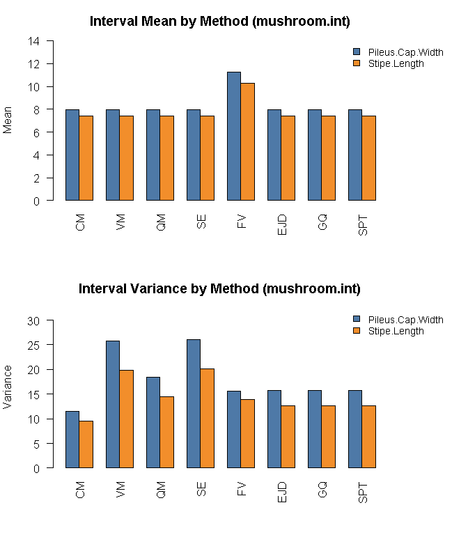

```r
cols <- c("#4E79A7", "#F28E2B")
par(mfrow = c(2, 1), mar = c(5, 4, 3, 6), las = 2, xpd = TRUE)

# --- Mean across eight methods ---
bp <- barplot(t(mean_mat), beside = TRUE, col = cols,
              main = "Interval Mean by Method (mushroom.int)",
              ylab = "Mean",
              ylim = c(0, max(mean_mat) * 1.25))
legend("topright", inset = c(-0.18, 0),
       legend = colnames(mean_mat), fill = cols, bty = "n", cex = 0.85)

# --- Variance across eight methods ---
bp <- barplot(t(var_mat), beside = TRUE, col = cols,
              main = "Interval Variance by Method (mushroom.int)",
              ylab = "Variance",
              ylim = c(0, max(var_mat) * 1.25))
legend("topright", inset = c(-0.18, 0),
       legend = colnames(var_mat), fill = cols, bty = "n", cex = 0.85)
```

## 4.2 Covariance and correlation

We compute the covariance and correlation between `Pileus.Cap.Width` and `Stipe.Length` across all eight methods. Note that EJD, GQ, and SPT methods require character variable names (not numeric indices).

```r
cov_list <- int_cov(mushroom.int, "Pileus.Cap.Width", "Stipe.Length", method)
cor_list <- int_cor(mushroom.int, "Pileus.Cap.Width", "Stipe.Length", method)

# Collect scalar values into named vectors for display and plotting
cov_vec <- sapply(cov_list, function(x) x[1, 1])
cor_vec <- sapply(cor_list, function(x) x[1, 1])

data.frame(Method = names(cov_vec), Covariance = round(cov_vec, 4),
           Correlation = round(cor_vec, 4), row.names = NULL)
```

```
#>   Method Covariance Correlation
#> 1     CM     8.4180      0.8047
#> 2     VM     8.1405      0.3556
#> 3     QM    14.0546      0.8599
#> 4     SE    20.2531      0.8847
#> 5     FV    11.3781      0.7724
#> 6    EJD     8.0520      0.5695
#> 7     GQ    11.4609      0.8106
#> 8    SPT    11.9723      0.8468
```

The SE method yields the largest covariance because it doubles the effective sample by stacking both endpoints, amplifying joint variation. VM produces the lowest correlation (0.36) because the vertex expansion introduces $2^p$ combinations per observation, many of which are non-informative.

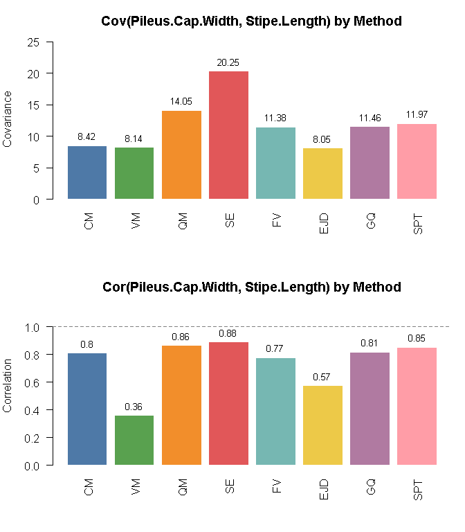

```r
par(mfrow = c(2, 1), mar = c(5, 4, 3, 1), las = 2)

# --- Covariance across eight methods ---
bar_cols <- c("#4E79A7", "#59A14F", "#F28E2B", "#E15759",
              "#76B7B2", "#EDC948", "#B07AA1", "#FF9DA7")
bp <- barplot(cov_vec, col = bar_cols, border = NA,
              main = "Cov(Pileus.Cap.Width, Stipe.Length) by Method",
              ylab = "Covariance",
              ylim = c(0, max(cov_vec) * 1.25))
text(bp, cov_vec, labels = round(cov_vec, 2), pos = 3, cex = 0.8)

# --- Correlation across eight methods ---
bp <- barplot(cor_vec, col = bar_cols, border = NA,
              main = "Cor(Pileus.Cap.Width, Stipe.Length) by Method",
              ylab = "Correlation",
              ylim = c(0, 1.15))
text(bp, cor_vec, labels = round(cor_vec, 2), pos = 3, cex = 0.8)
abline(h = 1, lty = 2, col = "grey50")
```

# 5 Geometric Properties

Geometric functions characterize the shape and spatial properties of individual intervals and relationships between interval variables.

## 5.1 Width, radius, center, and midrange

```r
data(mushroom.int)

# Width = upper - lower
head(int_width(mushroom.int, "Stipe.Length"))
```

```
#>   Stipe.Length
#> 1            5
#> 2           10
#> 3            6
#> 4            3
#> 5            3
#> 6            6
```

```r
# Radius = width / 2
head(int_radius(mushroom.int, "Stipe.Length"))
```

```
#>   Stipe.Length
#> 1          2.5
#> 2          5.0
#> 3          3.0
#> 4          1.5
#> 5          1.5
#> 6          3.0
```

```r
# Center = (lower + upper) / 2
head(int_center(mushroom.int, "Stipe.Length"))
```

```
#>   Stipe.Length
#> 1          6.5
#> 2          9.0
#> 3          8.0
#> 4          5.5
#> 5          3.5
#> 6          7.0
```

```r
# Midrange
head(int_midrange(mushroom.int, "Stipe.Length"))
```

```
#>   Stipe.Length
#> 1          2.5
#> 2          5.0
#> 3          3.0
#> 4          1.5
#> 5          1.5
#> 6          3.0
```

## 5.2 Overlap and containment

These functions measure the degree to which intervals from two variables overlap or contain each other, observation by observation:

```r
# Overlap between two interval variables
head(int_overlap(mushroom.int, "Stipe.Length", "Stipe.Thickness"))
```

```
#>   Stipe.Length_Stipe.Thickness
#> 1                    0.0000000
#> 2                    0.0000000
#> 3                    0.0000000
#> 4                    0.1250000
#> 5                    0.1428571
#> 6                    0.0000000
```

```r
# Containment: proportion of var_name2 contained within var_name1
head(int_containment(mushroom.int, "Stipe.Length", "Stipe.Thickness"))
```

```
#>   Stipe.Length_in_Stipe.Thickness
#> 1                           FALSE
#> 2                           FALSE
#> 3                           FALSE
#> 4                           FALSE
#> 5                           FALSE
#> 6                           FALSE
```

# 6 Position and Scale Measures

## 6.1 Median and quantiles

```r
data(mushroom.int)

# Median (default method = "CM")
int_median(mushroom.int, "Stipe.Length")
```

```
#>    Stipe.Length
#> CM            7
```

```r
# Quantiles
int_quantile(mushroom.int, "Stipe.Length", probs = c(0.25, 0.5, 0.75))
```

```
#> $CM
#>     Stipe.Length
#> 25%         4.75
#> 50%         7.00
#> 75%         9.25
```

```r
# Compare median across methods
int_median(mushroom.int, "Stipe.Length", method = c("CM", "FV"))
```

```
#>    Stipe.Length
#> CM     7.000000
#> FV     9.405092
```

## 6.2 Range, IQR, MAD, and mode

```r
# Range (max - min)
int_range(mushroom.int, "Stipe.Length")
```

```
#>    Stipe.Length
#> CM         11.5
```

```r
# Interquartile range (Q3 - Q1)
int_iqr(mushroom.int, "Stipe.Length")
```

```
#>     Stipe.Length
#> IQR          4.5
```

```r
# Median absolute deviation
int_mad(mushroom.int, "Stipe.Length")
```

```
#>    Stipe.Length
#> CM          2.5
```

```r
# Mode (histogram-based estimation)
int_mode(mushroom.int, "Stipe.Length")
```

```
#>    Stipe.Length
#> CM         8.75
```

# 7 Robust Statistics

Robust statistics reduce the influence of outliers by trimming or winsorizing extreme values.

## 7.1 Trimmed and winsorized means

```r
data(mushroom.int)

# Compare standard mean vs trimmed mean (10% trim)
int_mean(mushroom.int, "Stipe.Length", method = "CM")
```

```
#>    Stipe.Length
#> CM     7.391304
```

```r
int_trimmed_mean(mushroom.int, "Stipe.Length", trim = 0.1, method = "CM")
```

```
#>    Stipe.Length
#> CM     7.289474
```

```r
# Winsorized mean: extreme values are replaced (not removed)
int_winsorized_mean(mushroom.int, "Stipe.Length", trim = 0.1, method = "CM")
```

```
#>    Stipe.Length
#> CM     7.282609
```

## 7.2 Trimmed and winsorized variances

```r
int_var(mushroom.int, "Stipe.Length", method = "CM")
```

```
#>    Stipe.Length
#> CM     9.544466
```

```r
int_trimmed_var(mushroom.int, "Stipe.Length", trim = 0.1, method = "CM")
```

```
#>    Stipe.Length
#> CM     6.119883
```

```r
int_winsorized_var(mushroom.int, "Stipe.Length", trim = 0.1, method = "CM")
```

```
#>    Stipe.Length
#> CM     7.564229
```

# 8 Distribution Shape

Shape functions characterize the distribution of interval-valued data.

```r
data(mushroom.int)

# Skewness: asymmetry of the distribution
int_skewness(mushroom.int, "Stipe.Length", method = "CM")
```

```
#>    Stipe.Length
#> CM    0.2228348
```

```r
# Kurtosis: tail heaviness
int_kurtosis(mushroom.int, "Stipe.Length", method = "CM")
```

```
#>    Stipe.Length
#> CM    -1.065302
```

```r
# Symmetry coefficient
int_symmetry(mushroom.int, "Stipe.Length", method = "CM")
```

```
#>    Stipe.Length
#> CM     0.800247
```

```r
# Tailedness (related to kurtosis)
int_tailedness(mushroom.int, "Stipe.Length", method = "CM")
```

```
#>    Stipe.Length
#> CM    -1.065302
```

# 9 Similarity Measures

Similarity functions quantify how alike two interval variables are across all observations. Available measures include Jaccard, Dice, cosine, and overlap coefficient.

```r
data(mushroom.int)

int_jaccard(mushroom.int, "Stipe.Length", "Stipe.Thickness")
```

```
#>    Stipe.Length_Stipe.Thickness
#> 1                     0.0000000
#> 2                     0.0000000
#> 3                     0.0000000
#> 4                     0.1250000
#> 5                     0.1428571
#> 6                     0.0000000
#> 7                     0.0000000
#> 8                     0.0000000
#> 9                     0.0000000
#> 10                    0.0000000
#> 11                    0.0000000
#> 12                    0.0000000
#> 13                    0.0000000
#> 14                    0.0000000
#> 15                    0.0000000
#> 16                    0.0000000
#> 17                    0.0000000
#> 18                    0.0000000
#> 19                    0.0000000
#> 20                    0.0000000
#> 21                    0.0000000
#> 22                    0.0000000
#> 23                    0.0000000
```

```r
int_dice(mushroom.int, "Stipe.Length", "Stipe.Thickness")
```

```
#>    Stipe.Length_Stipe.Thickness
#> 1                     0.0000000
#> 2                     0.0000000
#> 3                     0.0000000
#> 4                     0.2222222
#> 5                     0.2500000
#> 6                     0.0000000
#> 7                     0.0000000
#> 8                     0.0000000
#> 9                     0.0000000
#> 10                    0.0000000
#> 11                    0.0000000
#> 12                    0.0000000
#> 13                    0.0000000
#> 14                    0.0000000
#> 15                    0.0000000
#> 16                    0.0000000
#> 17                    0.0000000
#> 18                    0.0000000
#> 19                    0.0000000
#> 20                    0.0000000
#> 21                    0.0000000
#> 22                    0.0000000
#> 23                    0.0000000
```

```r
int_cosine(mushroom.int, "Stipe.Length", "Stipe.Thickness")
```

```
#>        Stipe.Length_Stipe.Thickness
#> Cosine                    0.9257023
```

```r
int_overlap_coefficient(mushroom.int, "Stipe.Length", "Stipe.Thickness")
```

```
#>    Stipe.Length_Stipe.Thickness
#> 1                     0.0000000
#> 2                     0.0000000
#> 3                     0.0000000
#> 4                     0.3333333
#> 5                     0.5000000
#> 6                     0.0000000
#> 7                     0.0000000
#> 8                     0.0000000
#> 9                     0.0000000
#> 10                    0.0000000
#> 11                    0.0000000
#> 12                    0.0000000
#> 13                    0.0000000
#> 14                    0.0000000
#> 15                    0.0000000
#> 16                    0.0000000
#> 17                    0.0000000
#> 18                    0.0000000
#> 19                    0.0000000
#> 20                    0.0000000
#> 21                    0.0000000
#> 22                    0.0000000
#> 23                    0.0000000
```

Note: `int_tanimoto()` is equivalent to `int_jaccard()` for interval-valued data:

```r
int_tanimoto(mushroom.int, "Stipe.Length", "Stipe.Thickness")
```

```
#>    Stipe.Length_Stipe.Thickness
#> 1                     0.0000000
#> 2                     0.0000000
#> 3                     0.0000000
#> 4                     0.1250000
#> 5                     0.1428571
#> 6                     0.0000000
#> 7                     0.0000000
#> 8                     0.0000000
#> 9                     0.0000000
#> 10                    0.0000000
#> 11                    0.0000000
#> 12                    0.0000000
#> 13                    0.0000000
#> 14                    0.0000000
#> 15                    0.0000000
#> 16                    0.0000000
#> 17                    0.0000000
#> 18                    0.0000000
#> 19                    0.0000000
#> 20                    0.0000000
#> 21                    0.0000000
#> 22                    0.0000000
#> 23                    0.0000000
```

The `int_similarity_matrix()` function computes a pairwise similarity matrix across all interval variables:

```r
int_similarity_matrix(mushroom.int, method = "jaccard")
```

```
#>            1          2          3          4          5          6          7
#> 1  1.0000000 0.37037037 0.62380952 0.26666667 0.32539683 0.40873016 0.41269841
#> 2  0.3703704 1.00000000 0.37254902 0.16984127 0.28611111 0.55416667 0.18894831
#> 3  0.6238095 0.37254902 1.00000000 0.17857143 0.23611111 0.32900433 0.27380952
#> 4  0.2666667 0.16984127 0.17857143 1.00000000 0.11428571 0.33333333 0.29761905
#> 5  0.3253968 0.28611111 0.23611111 0.11428571 1.00000000 0.34166667 0.38333333
#> 6  0.4087302 0.55416667 0.32900433 0.33333333 0.34166667 1.00000000 0.32467532
#> 7  0.4126984 0.18894831 0.27380952 0.29761905 0.38333333 0.32467532 1.00000000
#> 8  0.4206349 0.27727273 0.54166667 0.23333333 0.51587302 0.26190476 0.48809524
#> 9  0.1479076 0.03030303 0.00000000 0.08333333 0.22222222 0.04761905 0.33333333
#> 10 0.2651515 0.06666667 0.28787879 0.00000000 0.17794486 0.02666667 0.10873440
#> 11 0.1111111 0.06060606 0.04166667 0.16666667 0.16666667 0.09523810 0.25000000
#> 12 0.4292929 0.61283422 0.41414141 0.12121212 0.57109557 0.55151515 0.29545455
#> 13 0.7444444 0.37142857 0.86772487 0.24074074 0.27042484 0.42028986 0.32063492
#> 14 0.2303030 0.48888889 0.25555556 0.00000000 0.51851852 0.36666667 0.13333333
```

[output cut: 81 more lines]

# 10 Uncertainty and Variability

These functions measure the uncertainty, variability, and information content of interval-valued data.

## 10.1 Entropy, CV, and dispersion

```r
data(mushroom.int)

# Shannon entropy (higher = more uncertainty)
int_entropy(mushroom.int, "Stipe.Length", method = "CM")
```

```
#>    Stipe.Length
#> CM     3.740953
```

```r
# Coefficient of variation (SD / mean)
int_cv(mushroom.int, "Stipe.Length", method = "CM")
```

```
#>    Stipe.Length
#> CM    0.4179793
```

```r
# Dispersion index
int_dispersion(mushroom.int, "Stipe.Length", method = "CM")
```

```
#>    Stipe.Length
#> CM     2.608696
```

## 10.2 Imprecision, granularity, uniformity, and information content

```r
# Imprecision: based on interval widths
int_imprecision(mushroom.int, "Stipe.Length")
```

```
#>             Stipe.Length
#> Imprecision    0.7882353
```

```r
# Granularity: variability in interval sizes
int_granularity(mushroom.int, "Stipe.Length")
```

```
#>             Stipe.Length
#> Granularity     0.506144
```

```r
# Uniformity: inverse of granularity (higher = more uniform)
int_uniformity(mushroom.int, "Stipe.Length")
```

```
#>            Stipe.Length
#> Uniformity    0.6639471
```

```r
# Normalized information content (between 0 and 1)
int_information_content(mushroom.int, "Stipe.Length", method = "CM")
```

```
#>    Stipe.Length
#> CM    0.8269928
```

# 11 Distance Measures

Distance functions compute dissimilarity between observations in interval-valued datasets. Available methods include: euclidean, hausdorff, ichino, de_carvalho, and others.

We use the interval columns of `car.int` for distance examples (excluding the character `Car` column):

```r
data(car.int)
car_num <- car.int[, 2:5]
head(car_num, 3)
```

```
#> # A tibble: 3 × 4
#>               Price      Max_Velocity      Accn_Time     Cylinder_Capacity
#>          <symblc_n>        <symblc_n>     <symblc_n>            <symblc_n>
#> 1 [260.50 : 460.00] [298.00 : 306.00]  [4.70 : 5.00] [5,935.00 : 5,935.00]
#> 2  [68.20 : 140.30] [216.00 : 250.00]  [6.70 : 9.70] [1,781.00 : 4,172.00]
#> 3 [123.80 : 171.40] [232.00 : 250.00] [5.40 : 10.10] [2,771.00 : 4,172.00]
```

## 11.1 Single distance method

```r
# Euclidean distance between observations
int_dist(car_num, method = "euclidean")
```

```
#>            1          2          3          4          5          6          7
#> 2 2970.35864
#> 3 2473.41498  496.95918
#> 4 1849.03463 1121.84802  625.03745
#> 5 1405.70741 1569.15384 1073.25182  456.94909
#> 6 2861.17713  150.18676  399.17381 1017.65776 1456.19073
#> 7 3348.56490  378.47417  875.27157 1500.20546 1946.33817  496.67582
#> 8 2446.96685  528.63346   74.77202  604.37782 1043.31078  416.61899  904.08797
```

## 11.2 Distance matrix

```r
# Return as a full matrix
dm <- int_dist_matrix(car_num, method = "hausdorff")
dm[1:5, 1:5]
```

```
#>        1      2      3      4      5
#> 1    0.0 4560.4 3523.7 3398.8 2425.5
#> 2 4560.4    0.0 1062.9 1374.6 2139.9
#> 3 3523.7 1062.9    0.0 1342.0 1590.2
#> 4 3398.8 1374.6 1342.0    0.0  998.8
#> 5 2425.5 2139.9 1590.2  998.8    0.0
```

## 11.3 Pairwise distance between variables

```r
int_pairwise_dist(car_num, "Price", "Max_Velocity", method = "euclidean")
```

```
#>      1      2      3      4      5      6      7      8
#>  58.25 128.75  93.40  43.15  19.50  54.80 144.45  95.45
```

## 11.4 All distance methods at once

```r
all_dists <- int_dist_all(car_num)
names(all_dists)
```

```
#>  [1] "GD"    "IY"    "L1"    "L2"    "CB"    "HD"    "EHD"   "nEHD"  "snEHD"
#> [10] "TD"    "WD"
```

# 12 Descriptive Statistics for Histogram-Valued Data

The `hist_mean`, `hist_var`, `hist_cov`, and `hist_cor` functions compute descriptive statistics for histogram-valued data (`MatH` objects). All four functions support the same four methods: **BG** (Bertrand and Goupil, 2000), **BD** (Billard and Diday, 2006), **B** (Billard, 2008), and **L2W** (L2 Wasserstein).

## 12.1 Mean and variance

We compute the mean and variance of `Cholesterol` and `Hemoglobin` in the `BLOOD` dataset using all four methods.

```r
all_methods <- c("BG", "BD", "B", "L2W")
var_names <- c("Cholesterol", "Hemoglobin")

# Compute mean for each variable and method
mean_mat <- sapply(all_methods, function(m) {
  sapply(var_names, function(v) hist_mean(BLOOD, v, method = m))
})
rownames(mean_mat) <- var_names
mean_mat
```

```
#>                    BG        BD         B       L2W
#> Cholesterol 180.67696 180.67696 180.67696 180.67696
#> Hemoglobin   12.36253  12.36253  12.36253  12.36252
```

```r
# Compute variance for each variable and method
var_mat <- sapply(all_methods, function(m) {
  sapply(var_names, function(v) hist_var(BLOOD, v, method = m))
})
rownames(var_mat) <- var_names
var_mat
```

```
#>                       BG          BD           B         L2W
#> Cholesterol 1002.3393384 381.9587931 400.0263122 388.1376335
#> Hemoglobin     0.5465906   0.2731987   0.2784401   0.2802215
```

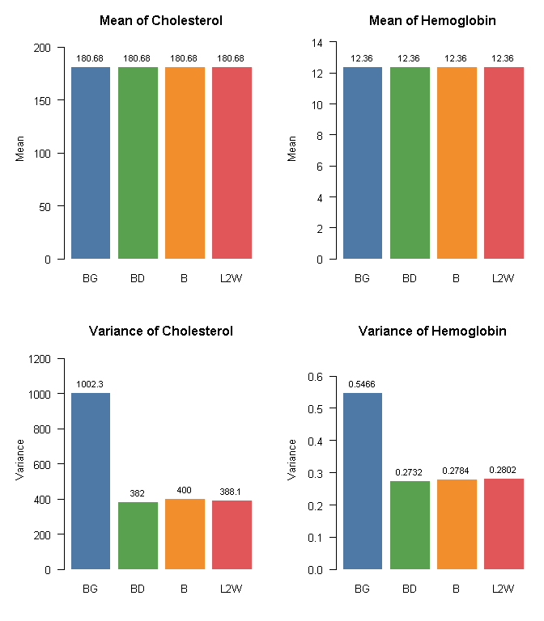

```r
bar_cols <- c("#4E79A7", "#59A14F", "#F28E2B", "#E15759")
par(mfrow = c(2, 2), mar = c(4, 5, 3, 1), las = 1)

# --- Mean: Cholesterol ---
bp <- barplot(mean_mat["Cholesterol", ], col = bar_cols, border = NA,
              main = "Mean of Cholesterol", ylab = "Mean",
              ylim = c(0, max(mean_mat["Cholesterol", ]) * 1.15))
text(bp, mean_mat["Cholesterol", ],
     labels = round(mean_mat["Cholesterol", ], 2), pos = 3, cex = 0.8)

# --- Mean: Hemoglobin ---
bp <- barplot(mean_mat["Hemoglobin", ], col = bar_cols, border = NA,
              main = "Mean of Hemoglobin", ylab = "Mean",
              ylim = c(0, max(mean_mat["Hemoglobin", ]) * 1.15))
text(bp, mean_mat["Hemoglobin", ],
     labels = round(mean_mat["Hemoglobin", ], 2), pos = 3, cex = 0.8)

# --- Variance: Cholesterol ---
bp <- barplot(var_mat["Cholesterol", ], col = bar_cols, border = NA,
              main = "Variance of Cholesterol", ylab = "Variance",
              ylim = c(0, max(var_mat["Cholesterol", ]) * 1.25))
text(bp, var_mat["Cholesterol", ],
     labels = round(var_mat["Cholesterol", ], 1), pos = 3, cex = 0.8)

# --- Variance: Hemoglobin ---
bp <- barplot(var_mat["Hemoglobin", ], col = bar_cols, border = NA,
              main = "Variance of Hemoglobin", ylab = "Variance",
              ylim = c(0, max(var_mat["Hemoglobin", ]) * 1.25))
text(bp, var_mat["Hemoglobin", ],
     labels = round(var_mat["Hemoglobin", ], 4), pos = 3, cex = 0.8)
```

## 12.2 Covariance and correlation

We compute the covariance and correlation between `Cholesterol` and `Hemoglobin` using all four methods.

```r
cov_vec <- sapply(all_methods, function(m)
  hist_cov(BLOOD, "Cholesterol", "Hemoglobin", method = m))
cor_vec <- sapply(all_methods, function(m)
  hist_cor(BLOOD, "Cholesterol", "Hemoglobin", method = m))

data.frame(Method = all_methods,
           Covariance = round(cov_vec, 4),
           Correlation = round(cor_vec, 4),
           row.names = NULL)
```

```
#>   Method Covariance Correlation
#> 1     BG    -5.1790     -0.2213
#> 2     BD    -5.2660     -0.2250
#> 3      B    -4.6927     -0.2005
#> 4    L2W    -5.0005     -0.4795
```

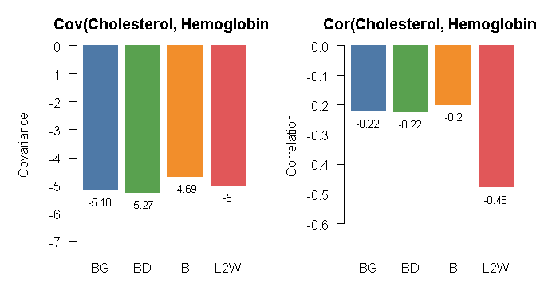

```r
par(mfrow = c(1, 2), mar = c(4, 5, 3, 1), las = 1)

# --- Covariance ---
bp <- barplot(cov_vec, col = bar_cols, border = NA,
              main = "Cov(Cholesterol, Hemoglobin)",
              ylab = "Covariance",
              ylim = c(min(cov_vec) * 1.35, 0))
text(bp, cov_vec, labels = round(cov_vec, 2), pos = 1, cex = 0.8)

# --- Correlation ---
bp <- barplot(cor_vec, col = bar_cols, border = NA,
              main = "Cor(Cholesterol, Hemoglobin)",
              ylab = "Correlation",
              ylim = c(min(cor_vec) * 1.4, 0))
text(bp, cor_vec, labels = round(cor_vec, 2), pos = 1, cex = 0.8)
abline(h = -1, lty = 2, col = "grey50")
```

# 13 Application: Benchmarking Symbolic Data Methods

## 13.1 Exploratory Data Analysis and Visualization

### 13.1.1 Aggregating classical data to symbolic data

The `aggregate_to_symbolic()` function converts a classical data frame into interval-valued or histogram-valued symbolic data via grouping (clustering, resampling, or a categorical variable).

```r
set.seed(42)
iris_int <- aggregate_to_symbolic(
  iris,
  type        = "int",
  group_by    = "kmeans",
  stratify_var = "Species",
  K           = 10
)
iris_int
```

```
#> # A tibble: 30 × 5
#>    cluster            Sepal.Length   Sepal.Width  Petal.Length   Petal.Width
#>  * <chr>                <symblc_n>    <symblc_n>    <symblc_n>    <symblc_n>
#>  1 setosa.cluster_1  [4.90 : 5.20] [3.20 : 3.60] [1.20 : 1.50] [0.10 : 0.30]
#>  2 setosa.cluster_4  [4.70 : 5.00] [3.00 : 3.20] [1.40 : 1.60] [0.10 : 0.30]
#>  3 setosa.cluster_7  [4.30 : 4.70] [2.90 : 3.20] [1.10 : 1.50] [0.10 : 0.20]
#>  4 setosa.cluster_5  [5.40 : 5.70] [3.80 : 3.90] [1.30 : 1.70] [0.30 : 0.40]
#>  5 setosa.cluster_3  [4.60 : 4.60] [3.40 : 3.60] [1.00 : 1.40] [0.20 : 0.30]
#>  6 setosa.cluster_8  [5.20 : 5.50] [3.40 : 3.70] [1.30 : 1.70] [0.20 : 0.40]
#>  7 setosa.cluster_9  [4.80 : 5.10] [3.30 : 3.50] [1.60 : 1.90] [0.20 : 0.60]
#>  8 setosa.cluster_2  [5.50 : 5.80] [4.00 : 4.40] [1.20 : 1.50] [0.20 : 0.40]
#>  9 setosa.cluster_10 [5.10 : 5.20] [3.70 : 4.10] [1.50 : 1.90] [0.10 : 0.40]
#> 10 setosa.cluster_6  [4.50 : 4.50] [2.30 : 2.30] [1.30 : 1.30] [0.30 : 0.30]
#> # ℹ 20 more rows
```

### 13.1.2 Visualization with ggInterval

The `ggInterval` package provides specialized plots for symbolic data including index image plots, PCA biplots, and radar plots. The following examples require `ggInterval` to be installed. Note: with 30 observations the index image and PCA plots may take several minutes to render.

```r
library(ggInterval)
library(ggplot2)

# Keep only interval columns (drop the 'sample' label column).
# Fix zero-width intervals from singleton clusters.
iris_int_num <- iris_int[, sapply(iris_int, inherits, "symbolic_interval")]
for (v in colnames(iris_int_num)) {
  cv <- unclass(iris_int_num[[v]])
  w  <- Im(cv) - Re(cv)
  fix <- which(w == 0)
  if (length(fix) > 0) {
    cv[fix] <- complex(real = Re(cv[fix]) - 1e-6, imaginary = Im(cv[fix]) + 1e-6)
    class(cv) <- c("symbolic_interval", "vctrs_vctr")
    iris_int_num[[v]] <- cv
  }
}
```

**Index image plot** – a heatmap of all interval variables:

[figure not shown]

```r
ggInterval_indexImage(iris_int_num, plotAll = TRUE)
```

**PCA biplot** – principal component analysis for interval data:

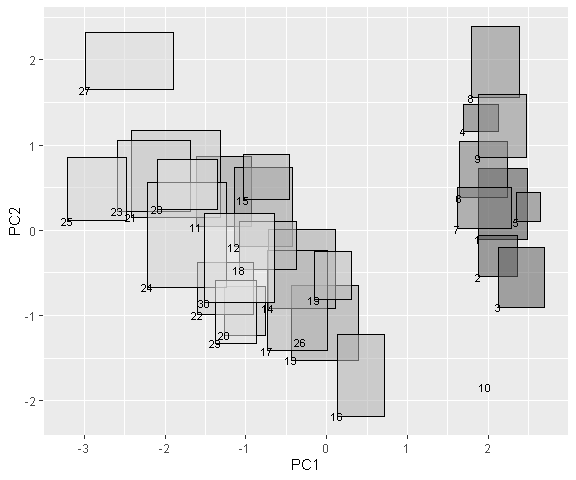

```
#> Call:
#> princomp(x = m[, 1:p])
#>
#> Standard deviations:
#>    Comp.1    Comp.2    Comp.3    Comp.4
#> 1.6672324 1.0000839 0.4167622 0.1953058
#>
#>  4  variables and  480 observations.
```

```r
ggInterval_PCA(iris_int_num)
```

**Radar plot** – multivariate comparison of interval columns from `environment.mix` (observations 4 and 6):

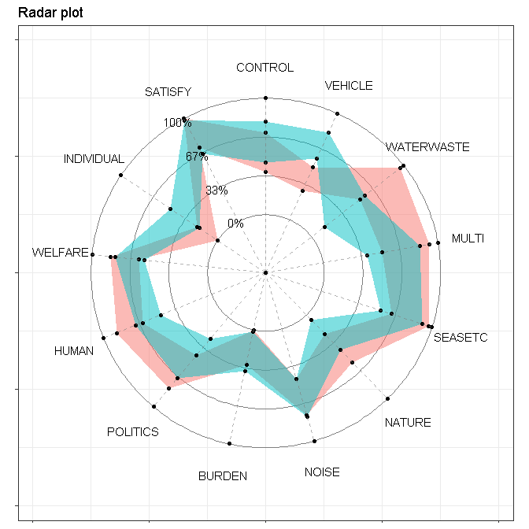

```r
data(environment.mix)
env_int <- environment.mix[, 5:17]
ggInterval_radarplot(env_int, plotPartial = c(4, 6),
                     showLegend = FALSE, addText = FALSE)
```

### 13.1.3 Interval time series visualization

We plot the first 12 months of the `irish_wind.its` dataset, showing each station’s wind speed interval as a bar with midpoint lines.

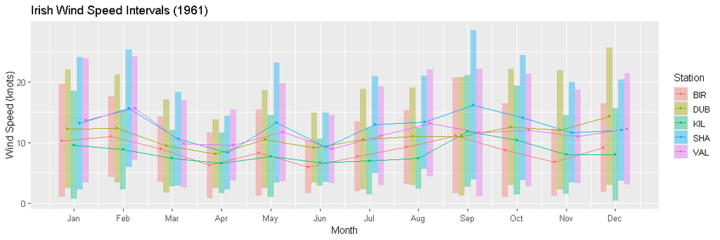

```r
data(irish_wind.its)
wind_sub <- irish_wind.its[1:12, ]

# Reshape to long format
stations <- c("BIR", "DUB", "KIL", "SHA", "VAL")
wind_long <- do.call(rbind, lapply(stations, function(st) {
  data.frame(
    month_num = seq_len(12),
    Station   = st,
    lower     = wind_sub[[paste0(st, "_l")]],
    upper     = wind_sub[[paste0(st, "_u")]],
    mid       = (wind_sub[[paste0(st, "_l")]] + wind_sub[[paste0(st, "_u")]]) / 2
  )
}))
wind_long$Station <- factor(wind_long$Station, levels = stations)

# Dodge bars for each station within each month
n_st  <- length(stations)
bar_w <- 0.6 / n_st
wind_long$st_idx <- as.numeric(wind_long$Station)
wind_long$x <- wind_long$month_num +
  (wind_long$st_idx - (n_st + 1) / 2) * bar_w

ggplot(wind_long) +
  geom_rect(aes(xmin = x - bar_w / 2, xmax = x + bar_w / 2,
                ymin = lower, ymax = upper, fill = Station),
            alpha = 0.4, color = NA) +
  geom_line(aes(x = x, y = mid, color = Station, group = Station),
            linewidth = 0.5) +
  geom_point(aes(x = x, y = mid, color = Station), size = 1) +
  scale_x_continuous(breaks = 1:12, labels = month.abb) +
  labs(title = "Irish Wind Speed Intervals (1961)",
       x = "Month", y = "Wind Speed (knots)") +
  theme_grey(base_size = 12)
```

## 13.2 Clustering for Interval-Valued Data

We benchmark three clustering algorithms on five interval-valued datasets using the quality index $1 - \text{WSS}/\text{TSS}$:

- `RSDA::sym.kmeans()` – K-means for symbolic data
- `symbolicDA::DClust()` – Distance-based symbolic clustering
- `symbolicDA::SClust()` – Symbolic clustering

Each method independently determines its own optimal number of clusters $k$ via an **n-adaptive elbow method**. For each method, we sweep $k$ from 2 to $k_{\max} = \min(n-1,\, 10,\, \max(3,\, \lfloor n/5 \rfloor))$ and compute the quality index at each $k$. The elbow is detected using an absolute gain threshold $\tau = \Delta_{\max} / (1 + n/100)$, where $\Delta_{\max}$ is the largest quality gain across all $k$. A 2-step lookahead skips temporary dips. This yields a higher threshold (fewer clusters) for small datasets and a lower threshold (more clusters allowed) for large datasets.

```r
library(symbolicDA)

set.seed(123)

datasets_clust_int <- list(
  list(name = "face.iGAP",              data = "face.iGAP"),
  list(name = "prostate.int",           data = "prostate.int"),
  list(name = "nycflights.int",         data = "nycflights.int"),
  list(name = "china_temp.int",         data = "china_temp.int"),
  list(name = "lisbon_air_quality.int", data = "lisbon_air_quality.int")
)

clust_int_results <- do.call(rbind, lapply(datasets_clust_int, function(ds) {
  tryCatch({
    data(list = ds$data)
    x <- get(ds$data)
    if (!inherits(x, "symbolic_tbl")) {
      x <- tryCatch(int_convert_format(x, to = "RSDA"), error = function(e) x)
      for (i in seq_along(x)) {
        if (is.complex(x[[i]]) && !inherits(x[[i]], "symbolic_interval"))
          class(x[[i]]) <- c("symbolic_interval", "vctrs_vctr")
      }
      if (!inherits(x, "symbolic_tbl"))
        class(x) <- c("symbolic_tbl", class(x))
    }
    x_int <- .get_interval_cols(x)
    n <- nrow(x_int); p <- ncol(x_int)
    k_max <- min(n - 1, 10, max(3, floor(n / 5)))

    d <- int_dist_matrix(x_int, method = "hausdorff")
    so <- simple2SO(.to_3d_array(x_int))

    km_qs <- dc_qs <- sc_qs <- setNames(rep(NA_real_, k_max - 1),
                                         as.character(2:k_max))
    for (k in 2:k_max) {
      set.seed(123)
      km_qs[as.character(k)] <- tryCatch({
        res <- sym.kmeans(x_int, k = k)
        1 - res$tot.withinss / res$totss
      }, error = function(e) NA)

      set.seed(123)
      dc_qs[as.character(k)] <- tryCatch({
        cl <- DClust(d, cl = k, iter = 100)
        .clust_quality(d, cl)
      }, error = function(e) NA)

      set.seed(123)
      sc_qs[as.character(k)] <- tryCatch({
        cl <- SClust(so, cl = k, iter = 100)
        .clust_quality(d, cl)
      }, error = function(e) NA)
    }

    km_k <- .find_optimal_k(km_qs, n); km_q <- km_qs[as.character(km_k)]
    dc_k <- .find_optimal_k(dc_qs, n); dc_q <- dc_qs[as.character(dc_k)]
    sc_k <- .find_optimal_k(sc_qs, n); sc_q <- sc_qs[as.character(sc_k)]

    data.frame(Dataset = ds$name, n = n, p = p,
               sym.kmeans = sprintf("%.4f (%d)", km_q, km_k),
               DClust     = sprintf("%.4f (%d)", dc_q, dc_k),
               SClust     = sprintf("%.4f (%d)", sc_q, sc_k))
  }, error = function(e) NULL)
}))
```

```r
kable(clust_int_results, row.names = FALSE,
      caption = "Table 4: Interval clustering quality (1 - WSS/TSS) with optimal k in parentheses")
```

Table 4: Interval clustering quality (1 - WSS/TSS) with optimal k in parentheses

| Dataset | n | p | sym.kmeans | DClust | SClust |
| --- | --- | --- | --- | --- | --- |
| face.iGAP | 27 | 6 | 0.6622 (3) | 0.6565 (4) | 0.6730 (4) |
| prostate.int | 97 | 9 | 0.8504 (3) | 0.8066 (5) | 0.8117 (4) |
| nycflights.int | 142 | 4 | 0.9540 (4) | 0.8141 (5) | 0.9061 (4) |
| china_temp.int | 899 | 4 | 0.9058 (5) | 0.8257 (5) | 0.8994 (7) |
| lisbon_air_quality.int | 1096 | 8 | 0.9191 (6) | 0.8944 (6) | 0.8893 (6) |

## 13.3 Clustering for Histogram-Valued Data

We benchmark three clustering algorithms on five histogram-valued datasets from `dataSDA`. Each dataset is converted from dataSDA’s histogram string format to `HistDAWass::MatH` objects for analysis:

- `WH_kmeans()` – K-means for histogram data
- `WH_fcmeans()` – Fuzzy C-means for histogram data
- `WH_hclust()` – Hierarchical clustering with Wasserstein distance

```r
set.seed(123)

datasets_clust_hist <- list(
  list(name = "age_pyramids.hist"),
  list(name = "ozone.hist"),
  list(name = "china_climate_season.hist"),
  list(name = "french_agriculture.hist"),
  list(name = "flights_detail.hist")
)

clust_hist_results <- do.call(rbind, lapply(datasets_clust_hist, function(ds) {
  tryCatch({
    data(list = ds$name, package = "dataSDA")
    raw <- get(ds$name)
    x <- .dataSDA_hist_to_MatH(raw)
    n <- nrow(x@M); p <- ncol(x@M)
    k_max <- min(n - 1, 10, max(3, floor(n / 5)))

    # Precompute Wasserstein distance matrix and hclust tree (shared across k)
    dm <- WH_MAT_DIST(x)
    set.seed(123)
    hc <- WH_hclust(x, simplify = TRUE)

    km_qs <- fc_qs <- hc_qs <- setNames(rep(NA_real_, k_max - 1),
                                         as.character(2:k_max))
    for (k in 2:k_max) {
      set.seed(123)
      km_qs[as.character(k)] <- tryCatch({
        res <- WH_kmeans(x, k = k)
        res$quality
      }, error = function(e) NA)

      set.seed(123)
      fc_qs[as.character(k)] <- tryCatch({
        res <- WH_fcmeans(x, k = k)
        res$quality
      }, error = function(e) NA)

      set.seed(123)
      hc_qs[as.character(k)] <- tryCatch({
        cl <- cutree(hc, k = k)
        .clust_quality(dm, cl)
      }, error = function(e) NA)
    }

    km_k <- .find_optimal_k(km_qs, n); km_q <- km_qs[as.character(km_k)]
    fc_k <- .find_optimal_k(fc_qs, n); fc_q <- fc_qs[as.character(fc_k)]
    hc_k <- .find_optimal_k(hc_qs, n); hc_q <- hc_qs[as.character(hc_k)]

    data.frame(Dataset = ds$name, n = n, p = p,
               WH_kmeans  = sprintf("%.4f (%d)", km_q, km_k),
               WH_fcmeans = sprintf("%.4f (%d)", fc_q, fc_k),
               WH_hclust  = sprintf("%.4f (%d)", hc_q, hc_k))
  }, error = function(e) NULL)
}))
```

```r
kable(clust_hist_results, row.names = FALSE,
      caption = "Table 5: Histogram clustering quality (1 - WSS/TSS) with optimal k in parentheses")
```

Table 5: Histogram clustering quality (1 - WSS/TSS) with optimal k in parentheses

| Dataset | n | p | WH_kmeans | WH_fcmeans | WH_hclust |
| --- | --- | --- | --- | --- | --- |
| age_pyramids.hist | 229 | 3 | 0.8703 (4) | 0.8396 (3) | 0.8623 (5) |
| ozone.hist | 78 | 4 | 0.7571 (3) | 0.7613 (3) | 0.8002 (4) |
| china_climate_season.hist | 60 | 56 | 0.4822 (3) | 0.4405 (3) | 0.5137 (4) |
| french_agriculture.hist | 22 | 4 | 0.7753 (4) | 0.6389 (3) | 0.6371 (3) |
| flights_detail.hist | 16 | 5 | 0.7071 (3) | 0.6992 (3) | 0.6874 (3) |

## 13.4 Classification for Interval-Valued Data

We benchmark three classifiers on five interval-valued datasets and report resubstitution accuracy:

- `MAINT.Data::lda()` – Linear discriminant analysis for interval data
- `MAINT.Data::qda()` – Quadratic discriminant analysis for interval data
- `e1071::svm()` – Support vector machine on lower/upper bound features

```r
library(MAINT.Data)
library(e1071)

datasets_class <- list(
  list(name = "cars.int",        data = "cars.int",
       class_col = "class",
       class_desc = "class: Utilitarian(7), Berlina(8), Sportive(8), Luxury(4)"),
  list(name = "china_temp.int",  data = "china_temp.int",
       class_col = "GeoReg",
       class_desc = "GeoReg: 6 regions"),
  list(name = "mushroom.int",    data = "mushroom.int",
       class_col = "Edibility",
       class_desc = "Edibility: T(4), U(2), Y(17)"),
  list(name = "ohtemp.int",      data = "ohtemp.int",
       class_col = "STATE",
       class_desc = "STATE: 10 groups"),
  list(name = "wine.int",        data = "wine.int",
       class_col = "class",
       class_desc = "class: 1(21), 2(12)")
)

class_results <- do.call(rbind, lapply(datasets_class, function(ds) {
  tryCatch({
    data(list = ds$data)
    x <- get(ds$data)
    grp <- .get_class_labels(x, ds$class_col)

    idata <- .build_IData(x)

    int_cols <- sapply(x, function(col) inherits(col, "symbolic_interval"))
    svm_df <- data.frame(row.names = seq_len(nrow(x)))
    for (v in names(x)[int_cols]) {
      cv <- unclass(x[[v]])
      svm_df[[paste0(v, "_l")]] <- Re(cv)
      svm_df[[paste0(v, "_u")]] <- Im(cv)
    }

    set.seed(123)
    lda_acc <- tryCatch({
      res <- MAINT.Data::lda(idata, grouping = grp)
      pred <- predict(res, idata)
      mean(pred$class == grp)
    }, error = function(e) NA)

    set.seed(123)
    qda_acc <- tryCatch({
      res <- MAINT.Data::qda(idata, grouping = grp)
      pred <- predict(res, idata)
      mean(pred$class == grp)
    }, error = function(e) NA)

    set.seed(123)
    svm_acc <- tryCatch({
      svm_df$class <- grp
      res <- svm(class ~ ., data = svm_df, kernel = "radial")
      pred <- predict(res, svm_df)
      mean(pred == grp)
    }, error = function(e) NA)

    data.frame(Dataset = ds$name, Response = ds$class_desc,
               LDA = lda_acc, QDA = qda_acc, SVM = svm_acc)
  }, error = function(e) NULL)
}))
```

```r
kable(class_results, digits = 4, row.names = FALSE,
      caption = "Table 6: Classification accuracy (resubstitution)")
```

Table 6: Classification accuracy (resubstitution)

| Dataset | Response | LDA | QDA | SVM |
| --- | --- | --- | --- | --- |
| cars.int | class: Utilitarian(7), Berlina(8), Sportive(8), Luxury(4) | 0.9259 | 0.9259 | 0.7778 |
| china_temp.int | GeoReg: 6 regions | 0.6952 | 0.5495 | 0.8087 |
| mushroom.int | Edibility: T(4), U(2), Y(17) | 0.8261 | 0.6957 | 0.7391 |
| ohtemp.int | STATE: 10 groups | 0.4720 | 0.1801 | 0.4596 |
| wine.int | class: 1(21), 2(12) | 0.9091 | 0.6667 | 0.9697 |

## 13.5 Regression for Interval-Valued Data

We benchmark five regression methods on five interval-valued datasets and report $R^2$:

- `RSDA::sym.lm()` – Symbolic linear regression (center method)
- `RSDA::sym.glm()` – LASSO regression via `glmnet` (center method)
- `RSDA::sym.rf()` – Symbolic random forest
- `RSDA::sym.rt()` – Symbolic regression tree
- `RSDA::sym.nnet()` – Symbolic neural network

```r
datasets_reg <- list(
  list(name = "abalone.iGAP",      data = "abalone.iGAP",
       response = "Length",           n_x = 6),
  list(name = "cardiological.int",  data = "cardiological.int",
       response = "pulse",            n_x = 4),
  list(name = "nycflights.int",     data = "nycflights.int",
       response = "distance",         n_x = 3),
  list(name = "oils.int",           data = "oils.int",
       response = "specific_gravity", n_x = 3),
  list(name = "prostate.int",       data = "prostate.int",
       response = "lpsa",             n_x = 8)
)

reg_results <- do.call(rbind, lapply(datasets_reg, function(ds) {
  tryCatch({
    data(list = ds$data)
    x <- get(ds$data)

    if (!inherits(x, "symbolic_tbl")) {
      x2 <- tryCatch(int_convert_format(x, to = "RSDA"), error = function(e) NULL)
      if (!is.null(x2)) {
        x <- x2
        for (i in seq_along(x)) {
          if (is.complex(x[[i]]) && !inherits(x[[i]], "symbolic_interval"))
            class(x[[i]]) <- c("symbolic_interval", "vctrs_vctr")
        }
        if (!inherits(x, "symbolic_tbl"))
          class(x) <- c("symbolic_tbl", class(x))
      } else {
        cn <- colnames(x)
        l_cols <- grep("_l$", cn, value = TRUE)
        vars <- sub("_l$", "", l_cols)
        out <- data.frame(row.names = seq_len(nrow(x)))
        for (v in vars) {
          lv <- x[[paste0(v, "_l")]]; uv <- x[[paste0(v, "_u")]]
          si <- complex(real = lv, imaginary = uv)
          class(si) <- c("symbolic_interval", "vctrs_vctr")
          out[[v]] <- si
        }
        class(out) <- c("symbolic_tbl", class(out))
        x <- out
      }
    }
    x_int <- .get_interval_cols(x)

    fml <- as.formula(paste(ds$response, "~ ."))
    nc <- data.frame(row.names = seq_len(nrow(x_int)))
    for (v in names(x_int)) {
      cv <- unclass(x_int[[v]])
      nc[[v]] <- (Re(cv) + Im(cv)) / 2
    }
    actual <- nc[[ds$response]]
    resp_idx <- which(names(x_int) == ds$response)
    .r2 <- function(a, p) 1 - sum((a - p)^2) / sum((a - mean(a))^2)

    set.seed(123)
    lm_r2 <- tryCatch({
      res <- sym.lm(fml, sym.data = x_int, method = "cm")
      summary(res)$r.squared
    }, error = function(e) NA)

    set.seed(123)
    glm_r2 <- tryCatch({
      res <- sym.glm(sym.data = x_int, response = resp_idx, method = "cm")
      pred <- as.numeric(predict(res, newx = as.matrix(nc[, -resp_idx]),
                                 s = "lambda.min"))
      .r2(actual, pred)
    }, error = function(e) NA)

    set.seed(123)
    rf_r2 <- tryCatch({
      res <- sym.rf(fml, sym.data = x_int, method = "cm")
      tail(res$rsq, 1)
    }, error = function(e) NA)

    set.seed(123)
    rt_r2 <- tryCatch({
      res <- sym.rt(fml, sym.data = x_int, method = "cm")
      .r2(actual, predict(res))
    }, error = function(e) NA)

    set.seed(123)
    nnet_r2 <- tryCatch({
      res <- sym.nnet(fml, sym.data = x_int, method = "cm")
      pred_sc <- as.numeric(res$net.result[[1]])
      pred <- pred_sc * res$data_c_sds[resp_idx] + res$data_c_means[resp_idx]
      .r2(actual, pred)
    }, error = function(e) NA)

    data.frame(Dataset = ds$name, Response = ds$response, p = ds$n_x,
               sym.lm = lm_r2, sym.glm = glm_r2, sym.rf = rf_r2,
               sym.rt = rt_r2, sym.nnet = nnet_r2)
  }, error = function(e) NULL)
}))
```

```r
kable(reg_results, digits = 4, row.names = FALSE,
      caption = "Table 7: Regression R-squared")
```

Table 7: Regression R-squared

| Dataset | Response | p | sym.lm | sym.glm | sym.rf | sym.rt | sym.nnet |
| --- | --- | --- | --- | --- | --- | --- | --- |
| abalone.iGAP | Length | 6 | 0.9893 | 0.9882 | 0.8976 | 0.6453 | 0.9932 |
| cardiological.int | pulse | 4 | 0.3772 | 0.3682 | 0.8014 | 0.5610 | 0.9996 |
| nycflights.int | distance | 3 | 0.9912 | 0.9910 | 0.9177 | 0.9857 | 0.9930 |
| oils.int | specific_gravity | 3 | 0.9115 | 0.6530 | 0.6577 | 0.0000 | 0.9679 |
| prostate.int | lpsa | 8 | 0.6622 | 0.6616 | 0.5299 | 0.6946 | 0.9879 |

# 14 Symbolic Dataset Donation/Submission Guidelines

We welcome contributions of high-quality datasets for symbolic data analysis. Submitted datasets will be made publicly available (or under specified constraints) to support research in machine learning, statistics, and related fields. You can submit the related files via email to wuhm@g.nccu.edu.tw or through the Google Form at [Symbolic Dataset Submission Form](https://forms.gle/AB6UCsNkrTzqDTp97). The submission requirements are as follows.

1. **Dataset Format**:
   - Preferred formats: `.csv`, `.xlsx`, or any symbolic format in plain text.
   - Compressed (`.zip` or `.gz`) if multiple files are included.
2. **Required Metadata**: Contributors must provide the following details:

   | **Field** | **Description** | **Example** |
   | --- | --- | --- |
   | **Dataset Name** | A clear, descriptive title. | “face recognition data” |
   | **Dataset Short Name** | A clear,abbreviation title. | “face data” |
   | **Authors** | Full names of donator. | “First name, Last name” |
   | **E-mail** | Contact email. | “abc123@gmail.com” |
   | **Institutes** | Affiliated organizations. | “-” |
   | **Country** | Origin of the dataset. | “France” |
   | **Dataset Descriptions** | Data descriptive | See ‘README’ |
   | **Sample Size** | Number of instances/rows. | 27 |
   | **Number of Variables** | Total features/columns (categorical/numeric). | 6 (interval) |
   | **Missing Values** | Indicate if missing values exist and how they are handled. | “None” / “Yes, marked as NA” |
   | **Variable Descriptions** | Detailed description of each column (name, type, units, range). | See ‘README’ |
   | **Source** | Original data source (if applicable). | “Leroy et al. (1996)” |
   | **References** | Citations for prior work using the dataset. | “Douzal-Chouakria, Billard, and Diday (2011)” |
   | **Applied Areas** | Relevant fields (e.g., biology, finance). | “Machine Learning” |
   | **Usage Constraints** | Licensing (CC-BY, MIT) or restrictions. | “Public domain” |
   | **Data Link** | URL to download the dataset (Google Drive, GitHub, etc.). | “(https)” |

3. **Quality Assurance**:
   - Datasets should be **clean** (no sensitive/private data).
4. **Optional (Recommended)**:
   - A companion `README` file with:
     - Dataset background.
     - Suggested use cases.
     - Known limitations.

# 15 Citation

Po-Wei Chen, Chun-houh Chen, Han-Ming Wu (2026), dataSDA: datasets and basic statistics for symbolic data analysis in R (v0.2.4). Technical report.